# Deep Learning with R Part 5

## Deep Prediction Models

Two common applications of auto-encoders and unsupervised learning are to identify anomalous data and to pre-train more complex models such as deep neural networks. Now train and build deep neural networks to develop prediction models (supervised learning).

- Deep feedforward neural networks
- Common activation functions: rectifiers, hyperbolic tangent, and maxout
- Picking hyperparameters
- Training and predicting new data from a deep neural network
- Walkthrough: training a deep neural network for automatic classification

### Feedforward Neural Networks

A deep feedforward neural network is designed to approximate a function, f(), that maps some set of input variables, x, to an output variable, y. They are called feedforward neural networks because information flows from the inputs through each successive layer as far as the output and there are no feedback or recursive loops (models including both forward and backward connections are referred to as recurrent neural networks).

Deep feedforward neural networks are applicable to a wide range of problems and are particularly useful for applications such as image classification. More generally, feedforward neural networks are useful for prediction and classification where there is a clearly defined outcome (what digit an image contains, whether someone is walking upstairs or walking on a flat surface, the presence/absence of disease, and so on). In these cases, there is no need for a feedback loop. Recurrent networks are useful for cases where feedback loops are important, such as for natural language processing.

A different function is learned for each successive layer. If sufficient hidden neurons are included in a layer, it can approximate to the desired degree of precision with many different types of functions. Even if the mapping from the final hidden layer to the outcome is a linear mapping with learned weights, feedforward neural networks can approximate nonlinear functions, by first applying non-linear transformations from the input layer to the hidden layer. *This is one of the key strengths of deep learning*. In linear regression, for example, the model learns the weights from the inputs to the outcome. However, the functional form must be specified. In deep feedforward neural networks, the transformations from the input layer to the hidden layer are learned as well as the weights from the hidden layer to the outcome. The model learns the functional form as well as the weights. The more hidden neurons, the closer the approximation. Thus for practical purposes, the model learns the functional form.

### Common Activation Functions

- rectifiers
- hyperbolic tangent
- maxout

The activation function determines the mapping between inputs and a hidden layer. It defines the functional form for how a neuron gets activated.

- linear activation function could be defined as: f(x) = x, in which case the value for the neuron would be the raw input, x, times the learned weight, a linear model. The problem with making activation functions linear is that this does not permit any non-linear functional forms to be learned.
- Previously, we used the hyperbolic tangent as an activation function, so f(x) = tanh(x). The hyperbolic tangent can work well in some cases, but a potential limitation is that, at either low or high values, it saturates
- Perhaps the most popular activation function currently, and a good first choice is known as a rectifier. There can be different kinds of rectifiers but, most commonly, linear rectifiers are used and are defined by the function f(x) = max(0, x). Linear rectifiers are flat below some threshold and are then linear. Despite their simplicity, linear rectifiers provide a non-linear transformation, and enough linear rectifiers can be used to approximate arbitrary non-linear functions, unlike using only linear activation functions.
- A final type of activation function is maxout. A maxout unit takes the maximum value of its inputs, although as usual this is after weighting so it is not the case that the input variable with the highest value will always win. Maxout activation functions seem to work particularly well with dropout.

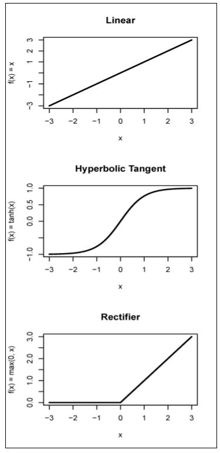

### Picking Hyperparameters

The parameters of a model typically refer to things such as the weights or bias/ intercept parameters. However, there are many other parameters that must be set at the offset and are not optimized or learned during model training. These are sometimes referred to as hyperparameters. Even the choice of model (for example, deep feedforward neural network, random forest, or support vector machine) can be seen as a hyperparameter.

Decisions must be made as to how many layers there should be, how many hidden neurons should be in each layer, whether there should be any skipping patterns or each layer should only have sequential connections. Unfortunately, there are no simple rules to follow to resolve many of these questions. Experience matters (as does patience workin through many experiments.)

Understanding what each hyperparameter helps to inform your decisions. If you start with a model and its performance is worse than is acceptable hyperparameters should be changed to allow greater capacity and flexibility in the model, for example, adding more hidden neurons, additional layers of hidden neurons, more training epochs, etc. If there is a large difference between the model’s performance on the training data and testing data, this may suggest the model is overfitting the data, in which case hyperparameters may be tweaked to reduce capacity or add more regularization.

### Training & Predicting Using Deep Neural Network

Get data that we have used before.

```r
# data and H2O setup
use.train.x <- read.table("../Essentials/data/X_train.txt")
use.train.y <- read.table("../Essentials/data/y_train.txt")[[1]]
use.test.x <- read.table("../Essentials/data/X_test.txt")
use.test.y <- read.table("../Essentials/data/y_test.txt")[[1]]

use.train <- cbind(use.train.x, Outcome = factor(use.train.y))
use.test <- cbind(use.test.x, Outcome = factor(use.test.y))

use.labels <- read.table("../Essentials/data/activity_labels.txt")
save(use.train.x, use.train.y, use.test.x, use.test.y, use.labels, use.train, use.test, file="../Essentials/Part5Data.RData")
```

```r
localH2O = h2o.init(max_mem_size = "3G", nthreads = 2)
```

```
##  Connection successful!
##
## R is connected to the H2O cluster:
##     H2O cluster uptime:         4 minutes 1 seconds
##     H2O cluster version:        3.10.4.6
##     H2O cluster version age:    2 months and 27 days
##     H2O cluster name:           H2O_started_from_R_czwea_tmg751
##     H2O cluster total nodes:    1
##     H2O cluster total memory:   2.59 GB
##     H2O cluster total cores:    4
##     H2O cluster allowed cores:  2
##     H2O cluster healthy:        TRUE
##     H2O Connection ip:          localhost
##     H2O Connection port:        54321
##     H2O Connection proxy:       NA
##     H2O Internal Security:      FALSE
##     R Version:                  R version 3.4.0 (2017-04-21)
```

```r
h2oactivity.train <- as.h2o(use.train, destination_frame = "h2oactivitytrain", h2o.no_progress())
h2oactivity.test <- as.h2o(use.test, destination_frame = "h2oactivitytest", h2o.no_progress())
```

Already learned the components of training a deep prediction model. Previously used `h2o.deeplearning()` for the auto-encoder models. Below, specify the variable names for both the x and y arguments.

- Activation function used is a linear rectifier
  - dropout both on the input variables (20%) and the hidden neurons (50%).
- Shallow network with only 50 hidden neurons and 10 training iterations.
- Cost (loss) function is cross-entropy

The model includes a total of 28,406 weights/biases. Biases are like intercepts or constant offsets. Because this is a feedforward neural network, there are only weights between adjacent layers. Input variables do not have biases, but hidden neurons and outcomes do. The 28,406 weights are made up from 561 x 50 = 28,050 weights between the input variables and the first layer of hidden neurons, 50 x 6 = 300 weights between the hidden neurons and the outcome (6 because there are different levels of the outcome), 50 biases for the hidden neurons, and 6 biases for the outcome.

Output also shows the number of layers and the number of units in each layer, the type of each unit, the dropout percentage, and other regularization and hyperparameter information.

A confusion matrix is printed which shows the actual outcome against the predicted outcome. The observed outcome is shown on the rows and the predicted outcome is shown on the columns. The diagonal indicates correct classification and the error rate by outcome level.

```r
mt1 <- h2o.deeplearning(x = colnames(use.train.x), y = "Outcome", training_frame = h2oactivity.train,
         activation = "RectifierWithDropout", hidden = c(50), epochs = 10, rate = .005, loss = "CrossEntropy",
         input_dropout_ratio = .2, hidden_dropout_ratios = c(.5), export_weights_and_biases = TRUE
)
mt1
```

```
## Model Details:
## ==============
##
## H2OMultinomialModel: deeplearning
## Model ID:  DeepLearning_model_R_1500924068859_3
## Status of Neuron Layers: predicting Outcome, 6-class classification, multinomial distribution, CrossEntropy loss, 28,406 weights/biases, 392.1 KB, 73,520 training samples, mini-batch size 1
##   layer units             type dropout       l1       l2 mean_rate
## 1     1   561            Input 20.00 %
## 2     2    50 RectifierDropout 50.00 % 0.000000 0.000000  0.001517
## 3     3     6          Softmax         0.000000 0.000000  0.005586
##   rate_rms momentum mean_weight weight_rms mean_bias bias_rms
## 1
## 2 0.002329 0.000000    0.001276   0.061798  0.356904 0.111535
## 3 0.048763 0.000000   -0.082723   0.751682 -0.034859 0.232519
##
##
## H2OMultinomialMetrics: deeplearning
## ** Reported on training data. **
## ** Metrics reported on full training frame **
##
## Training Set Metrics:
## =====================
##
## Extract training frame with `h2o.getFrame("h2oactivitytrain")`
## MSE: (Extract with `h2o.mse`) 0.0278768
## RMSE: (Extract with `h2o.rmse`) 0.1669635
## Logloss: (Extract with `h2o.logloss`) 0.09720854
## Mean Per-Class Error: 0.03490624
## Confusion Matrix: Extract with `h2o.confusionMatrix(<model>,train = TRUE)`)
## =========================================================================
## Confusion Matrix: vertical: actual; across: predicted
##           1    2   3    4    5    6  Error          Rate
## 1      1198   24   4    0    0    0 0.0228 =  28 / 1,226
## 2         6 1066   1    0    0    0 0.0065 =   7 / 1,073
## 3         0    7 979    0    0    0 0.0071 =     7 / 986
## 4         0    1   0 1247   29    9 0.0303 =  39 / 1,286
## 5         0    0   0  196 1178    0 0.1426 = 196 / 1,374
## 6         0    0   0    0    0 1407 0.0000 =   0 / 1,407
## Totals 1204 1098 984 1443 1207 1416 0.0377 = 277 / 7,352
##
## Hit Ratio Table: Extract with `h2o.hit_ratio_table(<model>,train = TRUE)`
## =======================================================================
## Top-6 Hit Ratios:
##   k hit_ratio
## 1 1  0.962323
## 2 2  0.999592
## 3 3  1.000000
## 4 4  1.000000
## 5 5  1.000000
## 6 6  1.000000
```

Extract and look at the features of the model using `h2o.deepfeatures()` specifying the model, data, and layer. The code extracts features and looks at the first few rows. The outcome is also included by default. Note the zeros in the features; these are there because we used a linear rectifier so values below zero are censored at zero.

```r
f <- as.data.frame(h2o.deepfeatures(mt1, h2oactivity.train, 1))
f[1:10, 1:5]
```

```
##    DF.L1.C1  DF.L1.C2 DF.L1.C3   DF.L1.C4 DF.L1.C5
## 1         0 1.3516159        0 2.18545823 1.184885
## 2         0 0.7740482        0 0.93790161 1.871019
## 3         0 0.9723284        0 1.47210223 2.032992
## 4         0 0.4094580        0 0.42089407 2.023395
## 5         0 1.0572178        0 0.28220448 2.082648
## 6         0 0.8586855        0 0.04326959 1.516681
## 7         0 0.7688233        0 0.53085204 1.911031
## 8         0 0.8078993        0 0.63518605 1.972278
## 9         0 0.7598714        0 1.02309824 1.901713
## 10        0 0.5702465        0 0.29638276 1.760497
```

Extract weights from each layer. The following code extracts weights and makes a heatmap so we can see if there are any clear patterns of certain input variables having higher weights to particular hidden neurons. There does not seem to be any particularly clear pattern . . . .

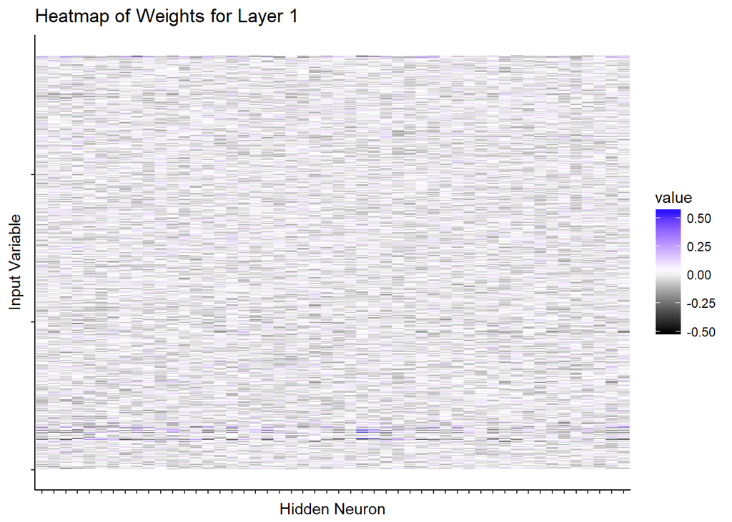

```r
w1 <- as.matrix(h2o.weights(mt1, 1))
## plot heatmap of the weights
tmp <- as.data.frame(t(w1))
tmp$Row <- 1:nrow(tmp)
tmp <- melt(tmp, id.vars = c("Row"))
p.heat <- ggplot(tmp, aes(variable, Row, fill = value)) +  geom_tile() +  scale_fill_gradientn(colours = c("black", "white", "blue")) +
     theme_classic() +  theme(axis.text = element_blank()) +  xlab("Hidden Neuron") +  ylab("Input Variable") +
     ggtitle("Heatmap of Weights for Layer 1")
print(p.heat)
```

Now predict using the model aboce using `h2o.predict()`:

```r
yhat.h2o <- as.data.frame(h2o.predict(mt1, newdata = h2oactivity.train))
head(yhat.h2o)
```

```
##   predict           p1           p2           p3           p4        p5
## 1       5 1.887241e-12 3.428944e-14 1.834806e-11 5.860797e-05 0.9999414
## 2       5 2.917158e-12 9.981883e-14 8.105297e-11 1.149743e-02 0.9885026
## 3       5 1.940634e-11 4.823232e-15 1.376429e-12 1.091599e-04 0.9998908
## 4       5 1.186853e-08 2.516775e-12 5.525173e-09 3.728496e-01 0.6271504
## 5       5 3.585208e-11 2.259339e-15 6.069917e-11 7.613101e-03 0.9923869
## 6       5 1.330888e-10 9.731329e-14 7.623168e-09 6.263605e-03 0.9937364
##             p6
## 1 3.595810e-10
## 2 2.635518e-09
## 3 5.985040e-11
## 4 1.633755e-08
## 5 1.354288e-09
## 6 9.730759e-09
```